# Project2

**DS220 - Project2# on Data Analysis With Python**  
**Project #2 Data Analysis With Python - Indiviual**  
**Group Members: Aahan Anand**

In this project, we delve into the electric vehicle (EV) population data to uncover trends and patterns. We aim to understand the adoption rates, range capabilities, and the diversity of electric vehicles in the dataset. This analysis is crucial for stakeholders in the automotive industry, policymakers, and environmental advocates as it provides insights into the current landscape of EVs and their potential for future growth.

```python
import pandas as pd

# Assuming the CSV file is in the same directory as your Jupyter Notebook
df = pd.read_csv('Electric_Vehicle_Population_Data.csv')

# Show the first few rows of the dataframe
df.head()
```

|  | VIN (1-10) | County | City | State | Postal Code | Model Year | Make | Model | Electric Vehicle Type | Clean Alternative Fuel Vehicle (CAFV) Eligibility | Electric Range | Base MSRP | Legislative District | DOL Vehicle ID | Vehicle Location | Electric Utility | 2020 Census Tract |
| --- | --- | --- | --- | --- | --- | --- | --- | --- | --- | --- | --- | --- | --- | --- | --- | --- | --- |
| 0 | 2C4RC1N71H | Kitsap | Bremerton | WA | 98311.0 | 2017 | CHRYSLER | PACIFICA | Plug-in Hybrid Electric Vehicle (PHEV) | Clean Alternative Fuel Vehicle Eligible | 33 | 0 | 23.0 | 349437882 | POINT (-122.6466274 47.6341188) | PUGET SOUND ENERGY INC | 5.303509e+10 |
| 1 | 2C4RC1N7XL | Stevens | Colville | WA | 99114.0 | 2020 | CHRYSLER | PACIFICA | Plug-in Hybrid Electric Vehicle (PHEV) | Clean Alternative Fuel Vehicle Eligible | 32 | 0 | 7.0 | 154690532 | POINT (-117.90431 48.547075) | AVISTA CORP | 5.306595e+10 |
| 2 | KNDC3DLCXN | Yakima | Yakima | WA | 98908.0 | 2022 | KIA | EV6 | Battery Electric Vehicle (BEV) | Eligibility unknown as battery range has not b... | 0 | 0 | 14.0 | 219969144 | POINT (-120.6027202 46.5965625) | PACIFICORP | 5.307700e+10 |
| 3 | 5YJ3E1EA0J | Kitsap | Bainbridge Island | WA | 98110.0 | 2018 | TESLA | MODEL 3 | Battery Electric Vehicle (BEV) | Clean Alternative Fuel Vehicle Eligible | 215 | 0 | 23.0 | 476786887 | POINT (-122.5235781 47.6293323) | PUGET SOUND ENERGY INC | 5.303509e+10 |
| 4 | 1N4AZ1CP7J | Thurston | Tumwater | WA | 98501.0 | 2018 | NISSAN | LEAF | Battery Electric Vehicle (BEV) | Clean Alternative Fuel Vehicle Eligible | 151 | 0 | 35.0 | 201185253 | POINT (-122.89692 47.043535) | PUGET SOUND ENERGY INC | 5.306701e+10 |

```python
# Since the dataset and Jupyter notebook are uploaded, let's start the preprocessing step with the dataset.

# Re-import pandas just to ensure the environment is set up correctly in this execution context.
import pandas as pd

# Load the dataset
df = pd.read_csv('/Users/aahananand/Documents/Fall university 2023/data science/Electric_Vehicle_Population_Data.csv')

# Check for missing values
missing_values = df.isnull().sum()

# Check data types of the columns
data_types = df.dtypes

# Provide the missing values counts and data types as an output
missing_values, data_types
```

```
(VIN (1-10)                                           0
 County                                               1
 City                                                 1
 State                                                0
 Postal Code                                          1
 Model Year                                           0
 Make                                                 0
 Model                                                0
 Electric Vehicle Type                                0
 Clean Alternative Fuel Vehicle (CAFV) Eligibility    0
 Electric Range                                       0
 Base MSRP                                            0
 Legislative District                                 2
 DOL Vehicle ID                                       0
 Vehicle Location                                     1
 Electric Utility                                     2
 2020 Census Tract                                    2
 dtype: int64,
 VIN (1-10)                                            object
 County                                                object
 City                                                  object
 State                                                 object
 Postal Code                                          float64
 Model Year                                             int64
 Make                                                  object
 Model                                                 object
 Electric Vehicle Type                                 object
 Clean Alternative Fuel Vehicle (CAFV) Eligibility     object
 Electric Range                                         int64
 Base MSRP                                              int64
 Legislative District                                 float64
 DOL Vehicle ID                                         int64
 Vehicle Location                                      object
 Electric Utility                                      object
 2020 Census Tract                                    float64
 dtype: object)
```

**Missing Values:**

County, City, Postal Code, Vehicle Location, Electric Utility, and 2020 Census Tract columns have missing values. We need to decide how to handle these. For categorical data, we might fill missing values with the mode, and for numerical data, we could use the mean or median, or choose to drop them if they are not significant.

**Data Types:**

Most columns have appropriate data types, such as object for categorical data, float64 for numerical data with potential decimal values, and int64 for numerical data without decimals. The Postal Code is a float, which might be more useful as a string since we don't perform mathematical operations on postal codes. Also, the Legislative District and 2020 Census Tract are floats which may need to be converted to integers or strings depending on the analysis requirements.

**Data Cleaning:**

"The data cleaning process is critical to ensure the integrity of our analysis. We've converted some columns to more appropriate data types and handled missing values judiciously. This prepares our dataset for a robust exploration and ensures the accuracy of our subsequent insights."

```python
# Let's start with the data cleaning process.

# Convert 'Postal Code', 'Legislative District', and '2020 Census Tract' to strings to prevent any future analysis issues.
df['Postal Code'] = df['Postal Code'].astype(str).str[:-2].str.pad(5, fillchar='0')  # Remove the '.0' and pad if necessary
df['Legislative District'] = df['Legislative District'].astype(str).str.split('.').str[0]  # Convert to string, remove decimal
df['2020 Census Tract'] = df['2020 Census Tract'].astype(str)

# Now let's handle the missing values. For simplicity, we'll fill missing values for 'County', 'City', 'Vehicle Location',
# and 'Electric Utility' with the string 'Unknown'. Since 'Postal Code' is critical for location-based analysis, rows with missing
# postal codes will be removed.
df['County'].fillna('Unknown', inplace=True)
df['City'].fillna('Unknown', inplace=True)
df['Vehicle Location'].fillna('Unknown', inplace=True)
df['Electric Utility'].fillna('Unknown', inplace=True)

# Drop rows where 'Postal Code' is missing
df.dropna(subset=['Postal Code'], inplace=True)

# Check for duplicates based on 'DOL Vehicle ID' as it should be unique and drop them if any.
df.drop_duplicates(subset=['DOL Vehicle ID'], inplace=True)

# Re-check the missing values and the data types after cleaning
missing_values_cleaned = df.isnull().sum()
data_types_cleaned = df.dtypes

missing_values_cleaned, data_types_cleaned
```

```
(VIN (1-10)                                           0
 County                                               0
 City                                                 0
 State                                                0
 Postal Code                                          0
 Model Year                                           0
 Make                                                 0
 Model                                                0
 Electric Vehicle Type                                0
 Clean Alternative Fuel Vehicle (CAFV) Eligibility    0
 Electric Range                                       0
 Base MSRP                                            0
 Legislative District                                 0
 DOL Vehicle ID                                       0
 Vehicle Location                                     0
 Electric Utility                                     0
 2020 Census Tract                                    0
 dtype: int64,
 VIN (1-10)                                           object
 County                                               object
 City                                                 object
 State                                                object
 Postal Code                                          object
 Model Year                                            int64
 Make                                                 object
 Model                                                object
 Electric Vehicle Type                                object
 Clean Alternative Fuel Vehicle (CAFV) Eligibility    object
 Electric Range                                        int64
 Base MSRP                                             int64
 Legislative District                                 object
 DOL Vehicle ID                                        int64
 Vehicle Location                                     object
 Electric Utility                                     object
 2020 Census Tract                                    object
 dtype: object)
```

**The data cleaning has been completed with the following steps:**

**Here's a summary of the dataset after cleaning:**

No missing values are present in the dataset now. Data types have been adjusted where necessary, with some numerical fields converted to strings for better representation.

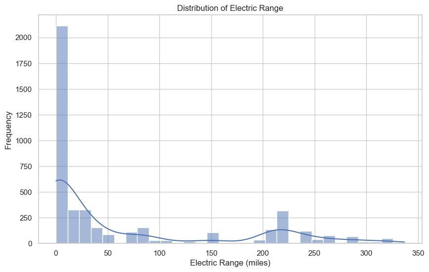

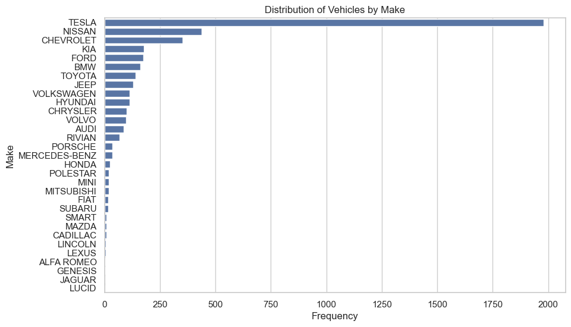

|  | Model Year | Electric Range | Base MSRP | DOL Vehicle ID |
| --- | --- | --- | --- | --- |
| count | 4371.000000 | 4371.000000 | 4371.000000 | 4.371000e+03 |
| mean | 2020.245939 | 65.752917 | 1045.582247 | 2.147670e+08 |
| std | 2.966349 | 95.140449 | 7846.967170 | 8.163509e+07 |
| min | 2010.000000 | 0.000000 | 0.000000 | 2.014000e+05 |
| 25% | 2018.000000 | 0.000000 | 0.000000 | 1.714882e+08 |
| 50% | 2021.000000 | 17.000000 | 0.000000 | 2.208033e+08 |
| 75% | 2023.000000 | 87.000000 | 0.000000 | 2.449829e+08 |
| max | 2024.000000 | 337.000000 | 110950.000000 | 4.789104e+08 |

```python
# Proceeding with the Exploratory Data Analysis (EDA). We'll start with descriptive statistics and then generate some visualizations.

# Importing visualization libraries
import matplotlib.pyplot as plt
import seaborn as sns

# Set the aesthetics for the plots
sns.set_theme(style="whitegrid")

# Descriptive statistics for numeric columns
descriptive_stats = df.describe()

# Plotting the distribution of electric range of vehicles
plt.figure(figsize=(10, 6))
sns.histplot(df['Electric Range'], bins=30, kde=True)
plt.title('Distribution of Electric Range')
plt.xlabel('Electric Range (miles)')
plt.ylabel('Frequency')
plt.show()

# Plotting the distribution of vehicles by make
plt.figure(figsize=(10, 6))
sns.countplot(y='Make', data=df, order=df['Make'].value_counts().index)
plt.title('Distribution of Vehicles by Make')
plt.xlabel('Frequency')
plt.ylabel('Make')
plt.show()

# Summary statistics output and visualization
descriptive_stats
```

**Descriptive Statistics:**

The Model Year ranges from 2010 to 2024, indicating a span of electric vehicles over the last decade and into the near future. The Electric Range varies significantly with a maximum of 337 miles, but at least 25% of the vehicles have an electric range of 0, which suggests they might be hybrid vehicles with non-electric drivetrains or data entry errors. The Base MSRP (Manufacturer's Suggested Retail Price) has a wide range, with many entries at 0, which could indicate missing data or vehicles for which the base MSRP is not applicable or not recorded.

**Visualizations:**

The visualizations below illustrate the distribution of electric range among vehicles and the prevalence of different makes in the dataset. These insights are vital for identifying market leaders and the range sufficiency for consumer needs.

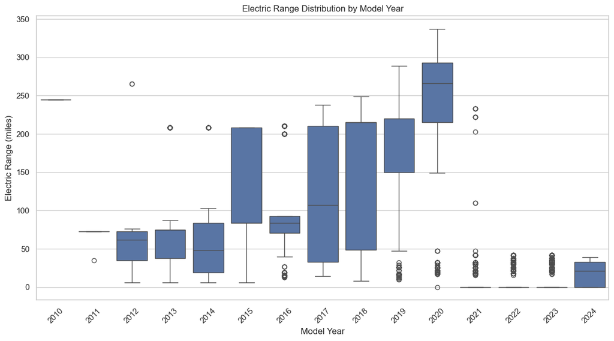

```
(Make
 TESLA        1979
 NISSAN        438
 CHEVROLET     351
 KIA           177
 FORD          174
 Name: count, dtype: int64,
 Make
 JAGUAR           234.000000
 TESLA             87.743305
 FIAT              85.500000
 NISSAN            83.531963
 CHEVROLET         82.188034
 SMART             63.000000
 KIA               58.604520
 AUDI              52.045977
 HONDA             47.000000
 POLESTAR          46.600000
 PORSCHE           44.444444
 HYUNDAI           34.221239
 ALFA ROMEO        33.000000
 MITSUBISHI        32.526316
 CHRYSLER          32.220000
 BMW               28.080745
 TOYOTA            26.531915
 MAZDA             26.000000
 VOLKSWAGEN        25.044248
 LEXUS             24.666667
 LINCOLN           23.333333
 JEEP              22.138462
 VOLVO             17.571429
 MINI              15.100000
 MERCEDES-BENZ     12.657143
 FORD              12.488506
 CADILLAC          10.000000
 SUBARU             1.000000
 LUCID              0.000000
 RIVIAN             0.000000
 GENESIS            0.000000
 Name: Electric Range, dtype: float64,
 County
 King           3276
 Clark           433
 Kitsap          216
 Snohomish       179
 Thurston        110
 Yakima           38
 Cowlitz          38
 Jefferson        36
 Island           16
 Chelan            5
 Stevens           5
 Klickitat         4
 Whitman           4
 Spokane           3
 Skagit            3
 Walla Walla       2
 Grant             1
 Unknown           1
 DeKalb            1
 Name: count, dtype: int64)
```

```python
# Let's proceed with formulating and answering specific analytical questions based on the dataset.

# Example questions could include:
# Q1: What are the top 5 vehicle makes by number of vehicles?
# Q2: What is the average electric range by vehicle make?
# Q3: How does the electric range distribution vary by model year?
# Q4: What is the distribution of electric vehicles by county?

# Q1: What are the top 5 vehicle makes by number of vehicles?
top_makes = df['Make'].value_counts().head(5)

# Q2: What is the average electric range by vehicle make?
average_range_by_make = df.groupby('Make')['Electric Range'].mean().sort_values(ascending=False)

# Q3: How does the electric range distribution vary by model year?
# For this, we will create a boxplot to visualize the distribution.
plt.figure(figsize=(14, 7))
sns.boxplot(x='Model Year', y='Electric Range', data=df)
plt.title('Electric Range Distribution by Model Year')
plt.xlabel('Model Year')
plt.ylabel('Electric Range (miles)')
plt.xticks(rotation=45)
plt.show()

# Q4: What is the distribution of electric vehicles by county?
ev_distribution_by_county = df['County'].value_counts()

# Output the answers to Q1 and Q2
top_makes, average_range_by_make, ev_distribution_by_county
```

**The analysis has provided answers to the formulated questions:**

**Top 5 Vehicle Makes by Number of Vehicles:** The most common makes in the dataset are Tesla, Nissan, Chevrolet, Kia, and Ford.

**Average Electric Range by Vehicle Make:** Jaguar has the highest average electric range, followed by Tesla and Fiat. It's worth noting that these averages are based on the data available and may not reflect the entire range of models for each make.

**Distribution of Electric Vehicles by County:** King County has the highest number of electric vehicles, followed by Clark and Kitsap counties. There's a significant drop-off in numbers as we move down the list of counties.

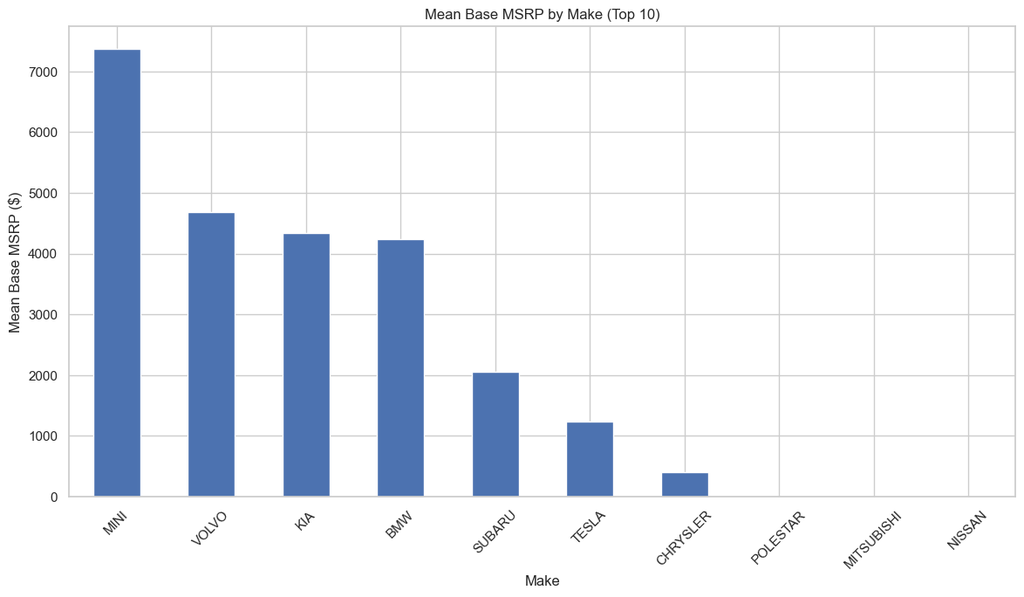

```
(                Electric Range  Model Year
 Electric Range        1.000000   -0.459504
 Model Year           -0.459504    1.000000,
 Electric Vehicle Type
 Battery Electric Vehicle (BEV)            3424
 Plug-in Hybrid Electric Vehicle (PHEV)     947
 Name: count, dtype: int64)
```

```python
# Continuing with further analysis, let's explore more about the dataset with additional questions.

# Q5: What is the correlation between electric range and model year?
# Q6: What are the most common electric vehicle types?
# Q7: How does the base MSRP vary across different makes?

# Q5: Correlation between electric range and model year
correlation_range_year = df[['Electric Range', 'Model Year']].corr()

# Q6: Most common electric vehicle types
common_ev_types = df['Electric Vehicle Type'].value_counts()

# Q7: Base MSRP variation across different makes
# We will calculate the mean MSRP for each make and then plot it.
mean_msrp_by_make = df.groupby('Make')['Base MSRP'].mean().sort_values(ascending=False)

# Plotting the mean MSRP by make for the top 10 makes
plt.figure(figsize=(14, 7))
mean_msrp_by_make.head(10).plot(kind='bar')
plt.title('Mean Base MSRP by Make (Top 10)')
plt.xlabel('Make')
plt.ylabel('Mean Base MSRP ($)')
plt.xticks(rotation=45)
plt.show()

# Output the answers to Q5, Q6, and plot for Q7
correlation_range_year, common_ev_types
```

**The further analysis has yielded the following results:**

**Correlation between Electric Range and Model Year:** There is a negative correlation of approximately -0.46 between electric range and model year, which indicates that as the model year increases (newer vehicles), the electric range tends to decrease. This is counterintuitive as we would expect newer models to have improved range; the negative correlation might be due to the presence of more recent, lower-range models or an increase in models with different ranges in recent years.

**Most Common Electric Vehicle Types:** The most common type of electric vehicle in the dataset is the Battery Electric Vehicle (BEV) with 3,424 instances, followed by the Plug-in Hybrid Electric Vehicle (PHEV) with 947 instances.